# 第二組目的=>分析各個feature組成人數，並找出對於Adaptability最有影響的條件

# 列出總數值資料表

```python
import numpy as np
import pandas as pd
import matplotlib.pyplot as plt
df = pd.read_csv("students_adaptability_level_online_education.csv",encoding='big5')
df
```

|  | Gender | Age | Education Level | Institution Type | IT Student | Location | Load-shedding | Financial Condition | Internet Type | Network Type | Class Duration | Self Lms | Device | Adaptivity Level |
| --- | --- | --- | --- | --- | --- | --- | --- | --- | --- | --- | --- | --- | --- | --- |
| 0 | Boy | 21-25 | University | Non Government | No | Yes | Low | Mid | Wifi | 4G | 3-6 | No | Tab | Moderate |
| 1 | Girl | 21-25 | University | Non Government | No | Yes | High | Mid | Mobile Data | 4G | 1-3 | Yes | Mobile | Moderate |
| 2 | Girl | 16-20 | College | Government | No | Yes | Low | Mid | Wifi | 4G | 1-3 | No | Mobile | Moderate |
| 3 | Girl | 11-15 | School | Non Government | No | Yes | Low | Mid | Mobile Data | 4G | 1-3 | No | Mobile | Moderate |
| 4 | Girl | 16-20 | School | Non Government | No | Yes | Low | Poor | Mobile Data | 3G | 0 | No | Mobile | Low |
| ... | ... | ... | ... | ... | ... | ... | ... | ... | ... | ... | ... | ... | ... | ... |
| 1200 | Girl | 16-20 | College | Non Government | No | Yes | Low | Mid | Wifi | 4G | 1-3 | No | Mobile | Low |
| 1201 | Girl | 16-20 | College | Non Government | No | No | High | Mid | Wifi | 4G | 3-6 | No | Mobile | Moderate |
| 1202 | Boy | 11-15 | School | Non Government | No | Yes | Low | Mid | Mobile Data | 3G | 1-3 | No | Mobile | Moderate |
| 1203 | Girl | 16-20 | College | Non Government | No | No | Low | Mid | Wifi | 4G | 1-3 | No | Mobile | Low |
| 1204 | Girl | 11-15 | School | Non Government | No | Yes | Low | Poor | Mobile Data | 3G | 1-3 | No | Mobile | Moderate |

1205 rows × 14 columns

```python
# 將Adaptivity Level數值化來表示，更好來分析程度
# Low -> 1, Moderate -> 2, High -> 3
df["Adaptivity Level"].unique()
df["level"] = df["Adaptivity Level"].map({ "Low":1, "Moderate":2, "High":3 })
df
#新增一個欄位在最右邊用數值表示Adaptivity Level
```

|  | Gender | Age | Education Level | Institution Type | IT Student | Location | Load-shedding | Financial Condition | Internet Type | Network Type | Class Duration | Self Lms | Device | Adaptivity Level | level |
| --- | --- | --- | --- | --- | --- | --- | --- | --- | --- | --- | --- | --- | --- | --- | --- |
| 0 | Boy | 21-25 | University | Non Government | No | Yes | Low | Mid | Wifi | 4G | 3-6 | No | Tab | Moderate | 2 |
| 1 | Girl | 21-25 | University | Non Government | No | Yes | High | Mid | Mobile Data | 4G | 1-3 | Yes | Mobile | Moderate | 2 |
| 2 | Girl | 16-20 | College | Government | No | Yes | Low | Mid | Wifi | 4G | 1-3 | No | Mobile | Moderate | 2 |
| 3 | Girl | 11-15 | School | Non Government | No | Yes | Low | Mid | Mobile Data | 4G | 1-3 | No | Mobile | Moderate | 2 |
| 4 | Girl | 16-20 | School | Non Government | No | Yes | Low | Poor | Mobile Data | 3G | 0 | No | Mobile | Low | 1 |
| ... | ... | ... | ... | ... | ... | ... | ... | ... | ... | ... | ... | ... | ... | ... | ... |
| 1200 | Girl | 16-20 | College | Non Government | No | Yes | Low | Mid | Wifi | 4G | 1-3 | No | Mobile | Low | 1 |
| 1201 | Girl | 16-20 | College | Non Government | No | No | High | Mid | Wifi | 4G | 3-6 | No | Mobile | Moderate | 2 |
| 1202 | Boy | 11-15 | School | Non Government | No | Yes | Low | Mid | Mobile Data | 3G | 1-3 | No | Mobile | Moderate | 2 |
| 1203 | Girl | 16-20 | College | Non Government | No | No | Low | Mid | Wifi | 4G | 1-3 | No | Mobile | Low | 1 |
| 1204 | Girl | 11-15 | School | Non Government | No | Yes | Low | Poor | Mobile Data | 3G | 1-3 | No | Mobile | Moderate | 2 |

1205 rows × 15 columns

# 分析每一個欄位中Adaptivity Level分布比例(圓餅圖)

```python
# 根據特定欄位繪製各項種類的"Adaptivity Level"分布比例圓餅圖
def GetPie( target="Gender" ):
    # 設定畫布相關設定
    figSize = 4
    wordSize = 12
    rowSize = df.nunique( axis=0 )[ target ] // 3 # 幾列
    if ( rowSize <= 1 ) :
        rowSize = 1
    else : # 超過三個
        figSize = rowSize * 2 # 畫面大小
        wordSize = rowSize * 6

    plt.figure( figsize=( figSize * 4 ,figSize * rowSize ) )

    # 繪製各種類圓餅圖
    i = 1
    for item in df[ target ].unique() :
        plt.subplot( rowSize, 3, i ) # 顯示於畫布的位置
        plt.title( item, {'fontsize': wordSize + 2 } )
        df_plot = df[ df[ target ]==item ]["Adaptivity Level"].value_counts().sort_index(ascending=True) # 每一種level數量
        labels = sorted( df[ df[ target ]==item ]["Adaptivity Level"].unique() ) # 有哪幾個level名稱
        plt.pie( df_plot, labels=labels, autopct = "%1.1f%%", textprops = {"fontsize" : wordSize }, )
        i += 1

    plt.show()
```

# Gender

| Gender | level |
| --- | --- |
| Boy | 1.737557 |
| Girl | 1.619926 |

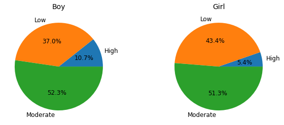

```python
target = "Gender"
# 平均level
display( df[[ "level", target ]].groupby( [ target ] ).mean() )

# Adaptivity Level分布
GetPie( target )
```

```python
# 上圖表現可看出Gender對Adaptivity Level影響不大
```

# Age

| Age | level |
| --- | --- |
| 1-5 | 1.790123 |
| 11-15 | 1.739377 |
| 16-20 | 1.500000 |
| 21-25 | 1.729947 |
| 26-30 | 1.647059 |
| 6-10 | 1.862745 |

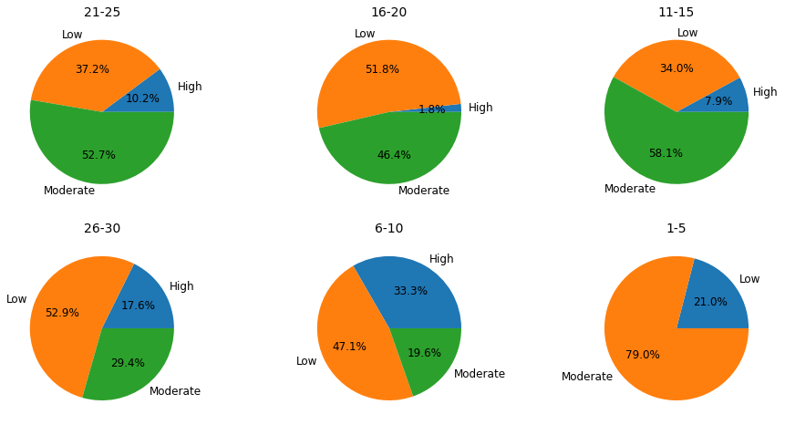

```python
target = "Age"
# 平均level
display( df[[ "level", target ]].groupby( [ target ] ).mean() )

# Adaptivity Level分布
GetPie( target )
```

```python
# Age 1-5 and Age 16-20 都幾乎沒有High Adaptivity Level的人
# 就平均Adaptivity Level-High而言 Age 16-20最低，Age 6-10最高
#以年齡層來看High Adaptivity Level 6-10開始逐漸減少，21-25開始逐漸增加
```

# Education Level

| Education Level | level |
| --- | --- |
| College | 1.465753 |
| School | 1.745283 |
| University | 1.719298 |

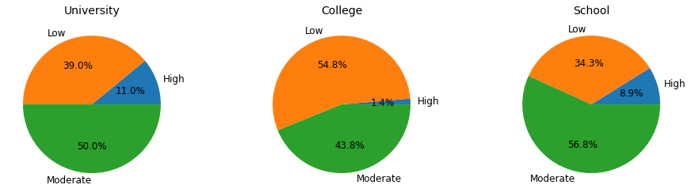

```python
target = "Education Level"
# 平均level
display( df[[ "level", target ]].groupby( [ target ] ).mean() )

# Adaptivity Level分布
GetPie( target )
```

```python
# College平均Adaptivity Level較低
```

# Institution Type

| Institution Type | level |
| --- | --- |
| Government | 1.439791 |
| Non Government | 1.798299 |

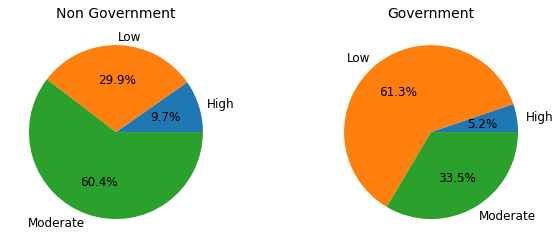

```python
target = "Institution Type"
# 平均level
display( df[[ "level", target ]].groupby( [ target ] ).mean() )

# Adaptivity Level分布
GetPie( target )
```

```python
# Non Government平均Adaptivity Level較高
```

# IT Student

| IT Student | level |
| --- | --- |
| No | 1.640400 |
| Yes | 1.815789 |

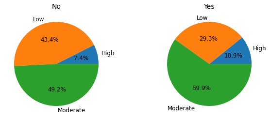

```python
target = "IT Student"
# 平均level
display( df[[ "level", target ]].groupby( [ target ] ).mean() )

# Adaptivity Level分布
GetPie( target )
```

```python
# IT Student的人平均Adaptivity Level較高
```

# Location

| Location | level |
| --- | --- |
| No | 1.396296 |
| Yes | 1.767914 |

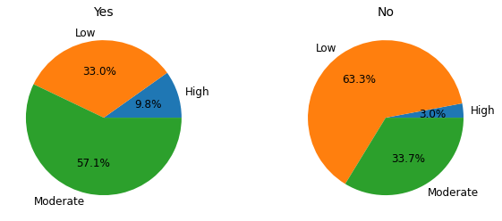

```python
target = "Location"
# 平均level
display( df[[ "level", target ]].groupby( [ target ] ).mean() )

# Adaptivity Level分布
GetPie( target )
```

```python
# Location in Town 的人平均Adaptivity Level較高
```

# Load-shedding

| Load-shedding | level |
| --- | --- |
| High | 1.567164 |
| Low | 1.708167 |

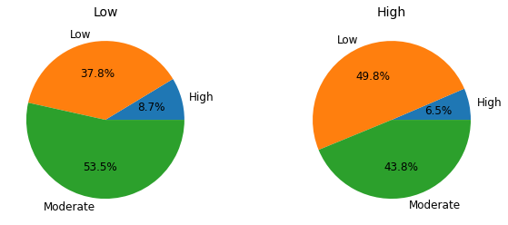

```python
target = "Load-shedding"
# 平均level
display( df[[ "level", target ]].groupby( [ target ] ).mean() )

# Adaptivity Level分布
GetPie( target )
```

```python
# Low level of load shedding的平均Adaptivity Level較高
```

# Financial Condition

| Financial Condition | level |
| --- | --- |
| Mid | 1.652620 |
| Poor | 1.557851 |
| Rich | 2.376471 |

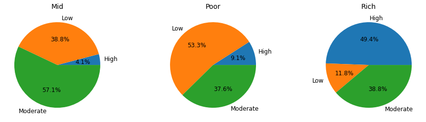

```python
target = "Financial Condition"
# 平均level
display( df[[ "level", target ]].groupby( [ target ] ).mean() )

# Adaptivity Level分布
GetPie( target )
```

```python
# Rich的人平均Adaptivity Level明顯較高，有一半人數都是High Adaptivity Level
```

# Internet Type

| Internet Type | level |
| --- | --- |
| Mobile Data | 1.63741 |
| Wifi | 1.74902 |

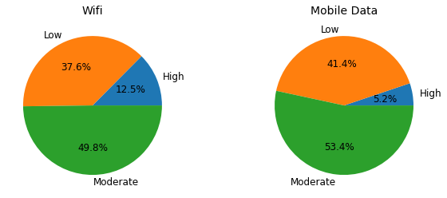

```python
target = "Internet Type"
# 平均level
display( df[[ "level", target ]].groupby( [ target ] ).mean() )

# Adaptivity Level分布
GetPie( target )
```

```python
# 使用wifi的平均Adaptivity Level略高於mobile data, 但影響不大
```

# Network Type

| Network Type | level |
| --- | --- |
| 2G | 1.157895 |
| 3G | 1.600973 |
| 4G | 1.741935 |

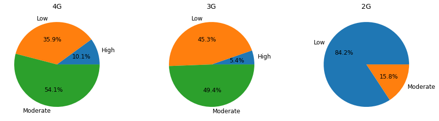

```python
target = "Network Type"
# 平均level
display( df[[ "level", target ]].groupby( [ target ] ).mean() )

# Adaptivity Level分布
GetPie( target )
```

```python
# Network Type等級越高，平均Adaptivity Level越高
```

# Class Duration

| Class Duration | level |
| --- | --- |
| 0 | 1.064935 |
| 1-3 | 1.752381 |
| 3-6 | 1.867299 |

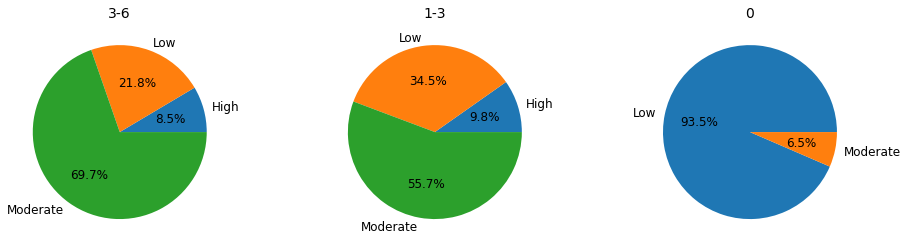

```python
target = "Class Duration"
# 平均level
display( df[[ "level", target ]].groupby( [ target ] ).mean() )

# Adaptivity Level分布
GetPie( target )
```

```python
# 花越多時間上課，平均Adaptivity Level越高
# class duration 為0者，幾乎都是Low Adaptivity Level
```

# Self Lms

| Self Lms | level |
| --- | --- |
| No | 1.640201 |
| Yes | 1.895238 |

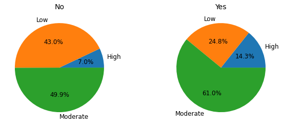

```python
target = "Self Lms"
# 平均level
display( df[[ "level", target ]].groupby( [ target ] ).mean() )

# Adaptivity Level分布
GetPie( target )
```

```python
# Have institution’s own LMS availability 的平均Adaptivity Level較高
```

# Device

| Device | level |
| --- | --- |
| Computer | 1.938272 |
| Mobile | 1.634748 |
| Tab | 2.000000 |

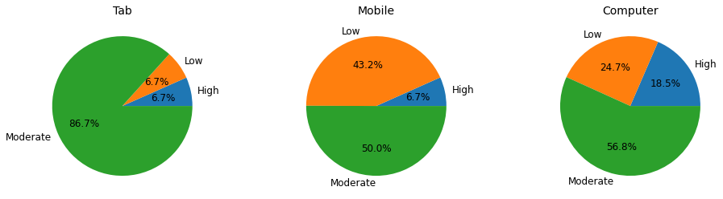

```python
target = "Device"
# 平均level
display( df[[ "level", target ]].groupby( [ target ] ).mean() )

# Adaptivity Level分布
GetPie( target )
```

```python
# 使用Tab多為 Moderate Adaptivity Level，且平均較其他兩者高
# 使用Mobile平均Adaptivity Level較低
```

# 同時看兩種條件下對於Adaptivity Level的影響，繪製折線圖與列表

```python
def AnalyzeTwoCondition( firstColumn, secondColumn ) :
    display( df.groupby([ firstColumn, secondColumn ]).agg([ "mean", "min", "max", "std", "count" ]) )
    df.groupby([ firstColumn, secondColumn ]).mean().plot( kind="line", figsize=( 15, 5 ) )
```

| Network Type | Class Duration | level mean | level min | level max | level std | level count |
| --- | --- | --- | --- | --- | --- | --- |
| 2G | 0 | 1.000000 | 1 | 1 | 0.000000 | 2 |
|  | 1-3 | 1.000000 | 1 | 1 | 0.000000 | 12 |
|  | 3-6 | 1.600000 | 1 | 2 | 0.547723 | 5 |
| 3G | 0 | 1.000000 | 1 | 1 | 0.000000 | 43 |
|  | 1-3 | 1.669967 | 1 | 3 | 0.589636 | 303 |
|  | 3-6 | 1.676923 | 1 | 3 | 0.562019 | 65 |
| 4G | 0 | 1.091743 | 1 | 2 | 0.289996 | 109 |
|  | 1-3 | 1.817143 | 1 | 3 | 0.624631 | 525 |
|  | 3-6 | 1.964539 | 1 | 3 | 0.498732 | 141 |

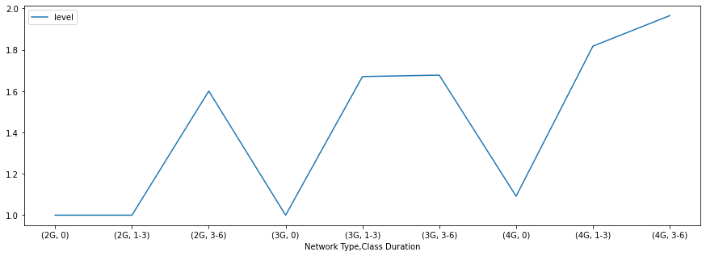

```python
AnalyzeTwoCondition( "Network Type", "Class Duration" )
```

```python
# Network Type越高，且 Class Duration越高者，Adaptivity Level越高
```

| Device | IT Student | level mean | level min | level max | level std | level count |
| --- | --- | --- | --- | --- | --- | --- |
| Computer | No | 1.863636 | 1 | 3 | 0.509943 | 44 |
|  | Yes | 1.966102 | 1 | 3 | 0.703255 | 118 |
| Mobile | No | 1.616307 | 1 | 3 | 0.620980 | 834 |
|  | Yes | 1.720670 | 1 | 3 | 0.519472 | 179 |
| Tab | No | 2.086957 | 2 | 3 | 0.288104 | 23 |
|  | Yes | 1.714286 | 1 | 2 | 0.487950 | 7 |

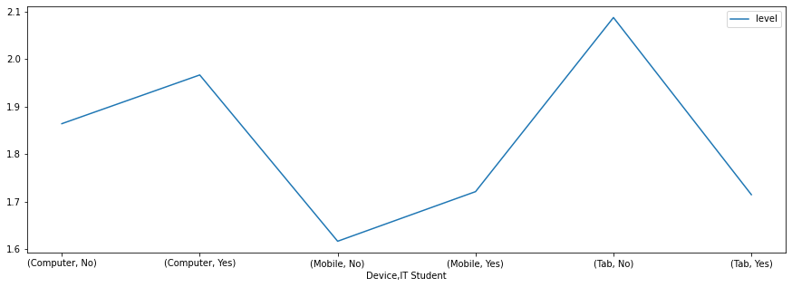

```python
AnalyzeTwoCondition( "Device", "IT Student" )
```

```python
# 使用computer與mobile，是IT Student的Adaptivity Level較高
# 然而使用Tab的非IT Student，平均Adaptivity Level遠高於其他狀況
```

| Financial Condition | Education Level | level mean | level min | level max | level std | level count |
| --- | --- | --- | --- | --- | --- | --- |
| Mid | College | 1.495000 | 1 | 3 | 0.530454 | 200 |
|  | School | 1.764881 | 1 | 3 | 0.552945 | 336 |
|  | University | 1.634503 | 1 | 3 | 0.550427 | 342 |
| Poor | College | 1.176471 | 1 | 2 | 0.392953 | 17 |
|  | School | 1.503497 | 1 | 3 | 0.579875 | 143 |
|  | University | 1.731707 | 1 | 3 | 0.770582 | 82 |
| Rich | College | 1.000000 | 1 | 1 | 0.000000 | 2 |
|  | School | 2.294118 | 1 | 3 | 0.641689 | 51 |
|  | University | 2.593750 | 1 | 3 | 0.665237 | 32 |

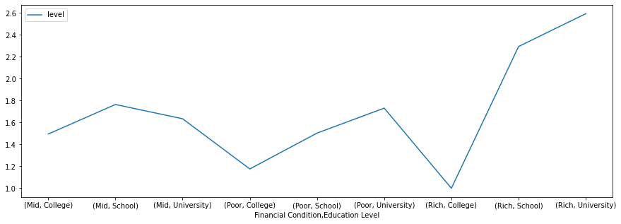

```python
AnalyzeTwoCondition( "Financial Condition",  "Education Level" )
```

```python
# Rich的Education Level為College者平均Adaptivity Level最低
# 但Rich的其他人平均Adaptivity Level遠高於其他種Financial Condition
```

# 將能數值化的欄位改以數值表示並最後合併以折線圖表示

# 最多六種值，以1~6作為範圍

```python
#欄位數值轉換
df_level = pd.DataFrame()
df_level["Age"] = df["Age"].map({ "1-5":1, "6-10":2, "11-15":3, "16-20":4, "21-25":5, "26-30":6 })
df_level["Education Level"] = df["Education Level"].map({ "School":1, "College":3.5, "University":6 })
df_level["Load-shedding"] = df["Load-shedding"].map({ "Low":1, "High":6 })
df_level["Network Type"] = df["Network Type"].map({ "2G":1, "3G":3.5, "4G":6 })
df_level["Class Duration"] = df["Class Duration"].map({ "0":1, "1-3":3.5, "3-6":6 })
df_level["Adaptivity Level"] = df["Adaptivity Level"].map({ "Low":1, "Moderate":3.5, "High":6 })

df_level
```

|  | Age | Education Level | Load-shedding | Network Type | Class Duration | Adaptivity Level |
| --- | --- | --- | --- | --- | --- | --- |
| 0 | 5 | 6.0 | 1 | 6.0 | 6.0 | 3.5 |
| 1 | 5 | 6.0 | 6 | 6.0 | 3.5 | 3.5 |
| 2 | 4 | 3.5 | 1 | 6.0 | 3.5 | 3.5 |
| 3 | 3 | 1.0 | 1 | 6.0 | 3.5 | 3.5 |
| 4 | 4 | 1.0 | 1 | 3.5 | 1.0 | 1.0 |
| ... | ... | ... | ... | ... | ... | ... |
| 1200 | 4 | 3.5 | 1 | 6.0 | 3.5 | 1.0 |
| 1201 | 4 | 3.5 | 6 | 6.0 | 6.0 | 3.5 |
| 1202 | 3 | 1.0 | 1 | 3.5 | 3.5 | 3.5 |
| 1203 | 4 | 3.5 | 1 | 6.0 | 3.5 | 1.0 |
| 1204 | 3 | 1.0 | 1 | 3.5 | 3.5 | 3.5 |

1205 rows × 6 columns

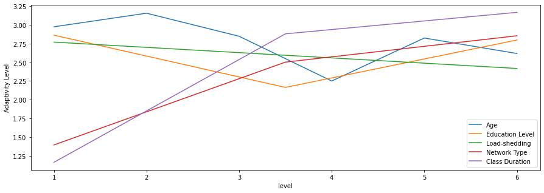

```python
# 畫折線圖
fig, ax = plt.subplots()
for target in df_level :
    # 對每種欄位(column)的每項level做Adaptivity Level平均
    if ( target == "Adaptivity Level" ) :
        continue
    else :
        df_temp_level = df_level[[ "Adaptivity Level", target ]].groupby( [ target ] ).mean() # 將不同level作為index，對於Adaptivity Level做平均
        df_temp_level = df_temp_level.rename( columns={ "Adaptivity Level": target } ) # 把重新命名column位，以便折線圖上顯示
        ax = df_temp_level.plot( kind="line", xlabel="level", ylabel="Adaptivity Level", ax=ax, figsize=( 15, 5 ) )
```

```python
# 對於Adaptivity Level平均而言
# Age越大反而Adaptivity Level越低的趨勢
# Load shedding與Adaptivity Level成反比，但趨勢並不是很明顯
# Education Level沒有明顯相關性
# Class Duration與Network Type都與Adaptivity Level成正比
```

# 分析欄位之間與適應性的相關性(個別與倆倆一起看)

```python
adapttability_df = pd.read_csv("students_adaptability_level_online_education.csv")
# All feature in this dataset are categorical data.

# Some feature are have only two category, so use one hot encoding to change the category to value.
# Gender、Institution Type、IT Student、Location、Load-shedding、Internet Type、Self Lms
adapttability_df["Gender"].replace("Boy",  1, inplace = True)
adapttability_df["Gender"].replace("Girl",  2, inplace = True)

adapttability_df["Institution Type"].replace("Non Government",  1, inplace = True)
adapttability_df["Institution Type"].replace("Government",  2, inplace = True)

adapttability_df["IT Student"].replace("No",  1, inplace = True)
adapttability_df["IT Student"].replace("Yes",  2, inplace = True)

adapttability_df["Location"].replace("No",  1, inplace = True)
adapttability_df["Location"].replace("Yes",  2, inplace = True)

adapttability_df["Load-shedding"].replace("Low",  1, inplace = True)
adapttability_df["Load-shedding"].replace("High",  2, inplace = True)

adapttability_df["Internet Type"].replace("Wifi",  1, inplace = True)
adapttability_df["Internet Type"].replace("Mobile Data",  2, inplace = True)

adapttability_df["Self Lms"].replace("No",  1, inplace = True)
adapttability_df["Self Lms"].replace("Yes",  2, inplace = True)

# Some feature are represent different degree, so use label encoding to change the category to value.
# Age、Education Level、Financial Condition、Network Type、Class Duration、Adaptivity Level
adapttability_df["Age"].replace("1-5", 1, inplace = True)
adapttability_df["Age"].replace("6-10",  2, inplace = True)
adapttability_df["Age"].replace("11-15",  3, inplace = True)
adapttability_df["Age"].replace("16-20", 4, inplace = True)
adapttability_df["Age"].replace("21-25",  5, inplace = True)
adapttability_df["Age"].replace("26-30",  6, inplace = True)

adapttability_df["Education Level"].replace("School",  1, inplace = True)
adapttability_df["Education Level"].replace("University",  2, inplace = True)
adapttability_df["Education Level"].replace("College",  3, inplace = True)

adapttability_df["Financial Condition"].replace("Poor",  1, inplace = True)
adapttability_df["Financial Condition"].replace("Mid",  2, inplace = True)
adapttability_df["Financial Condition"].replace("Rich",  3, inplace = True)

adapttability_df["Network Type"].replace("2G",  1, inplace = True)
adapttability_df["Network Type"].replace("3G",  2, inplace = True)
adapttability_df["Network Type"].replace("4G",  3, inplace = True)

adapttability_df["Class Duration"].replace("0",  1, inplace = True)
adapttability_df["Class Duration"].replace("1-3",  2, inplace = True)
adapttability_df["Class Duration"].replace("3-6",  3, inplace = True)

adapttability_df["Adaptivity Level"].replace("Low",  1, inplace = True)
adapttability_df["Adaptivity Level"].replace("Moderate",  2, inplace = True)
adapttability_df["Adaptivity Level"].replace("High",  3, inplace = True)


# Some feature is didn't represent different degree, and we guess that some information can be extracted on the frequency.
# So use frequency encoding to change the category to value.
# Device
adapttability_df["Device"].replace("Tab",  adapttability_df["Device"].where(adapttability_df["Device"] == 'Tab').count(), inplace = True)
adapttability_df["Device"].replace("Mobile",  adapttability_df["Device"].where(adapttability_df["Device"] == 'Mobile').count(), inplace = True)
adapttability_df["Device"].replace("Computer",  adapttability_df["Device"].where(adapttability_df["Device"] == 'Computer').count(), inplace = True)
```

```python
# Divide the dataset into three parts to easily view the results.
adapt_first_part = adapttability_df[["Gender", "Age", "Education Level", "Institution Type", "Adaptivity Level"]].copy()
adapt_second_part = adapttability_df[["IT Student", "Location", "Load-shedding", "Financial Condition", "Adaptivity Level"]].copy()
adapt_third_part = adapttability_df[["Internet Type", "Network Type", "Class Duration", "Self Lms", "Device", "Adaptivity Level"]].copy()
```

```python
display(adapt_first_part.corr())
display(adapt_second_part.corr())
display(adapt_third_part.corr())
```

|  | Gender | Age | Education Level | Institution Type | Adaptivity Level |
| --- | --- | --- | --- | --- | --- |
| Gender | 1.000000 | -0.206355 | 0.026615 | -0.106910 | -0.094695 |
| Age | -0.206355 | 1.000000 | 0.595284 | 0.252069 | -0.054810 |
| Education Level | 0.026615 | 0.595284 | 1.000000 | 0.300672 | -0.144348 |
| Institution Type | -0.106910 | 0.252069 | 0.300672 | 1.000000 | -0.269948 |
| Adaptivity Level | -0.094695 | -0.054810 | -0.144348 | -0.269948 | 1.000000 |

|  | IT Student | Location | Load-shedding | Financial Condition | Adaptivity Level |
| --- | --- | --- | --- | --- | --- |
| IT Student | 1.000000 | 0.009697 | 0.186005 | 0.070494 | 0.123269 |
| Location | 0.009697 | 1.000000 | -0.245380 | 0.109784 | 0.250746 |
| Load-shedding | 0.186005 | -0.245380 | 1.000000 | -0.188949 | -0.085063 |
| Financial Condition | 0.070494 | 0.109784 | -0.188949 | 1.000000 | 0.238270 |
| Adaptivity Level | 0.123269 | 0.250746 | -0.085063 | 0.238270 | 1.000000 |

|  | Internet Type | Network Type | Class Duration | Self Lms | Device | Adaptivity Level |
| --- | --- | --- | --- | --- | --- | --- |
| Internet Type | 1.000000 | -0.335989 | -0.250804 | -0.084661 | 0.422328 | -0.089234 |
| Network Type | -0.335989 | 1.000000 | -0.019866 | -0.207056 | -0.131521 | 0.141849 |
| Class Duration | -0.250804 | -0.019866 | 1.000000 | 0.247624 | -0.340853 | 0.328118 |
| Self Lms | -0.084661 | -0.207056 | 0.247624 | 1.000000 | -0.237762 | 0.156557 |
| Device | 0.422328 | -0.131521 | -0.340853 | -0.237762 | 1.000000 | -0.186008 |
| Adaptivity Level | -0.089234 | 0.141849 | 0.328118 | 0.156557 | -0.186008 | 1.000000 |

# We can see that the first three that correlate with adaptivity level are:

1. Class Duration (positive correlation) : 0.328118
2. Institution Type (negative correlation) : -0.269948
3. Location (positive correlation) : 0.250746

```python
import seaborn as sns
```

# The scatter plot is a common way to show how the data distributed. the following is try to use scatter plot to show where exist the data.

But the scatter plot can't show many data in one dot. The dot has only one data looks same as the dot has 10 or more data. So the scatter plot can't show the density of this dataset. And because we use encoding to handle category data. So it can exist data in few dot, not everywhere.So a little different data can fill up all possible dot and we can't see more information in scatter plot.¶

# Conclusion:scatter plot is not suitable to this dataset¶

But for one pair of data: Age and Education Level, their correlation is 0.595284. High and positive correlation. We can see the correlation trend on scatter plot. (the second row and third column on the first plot)

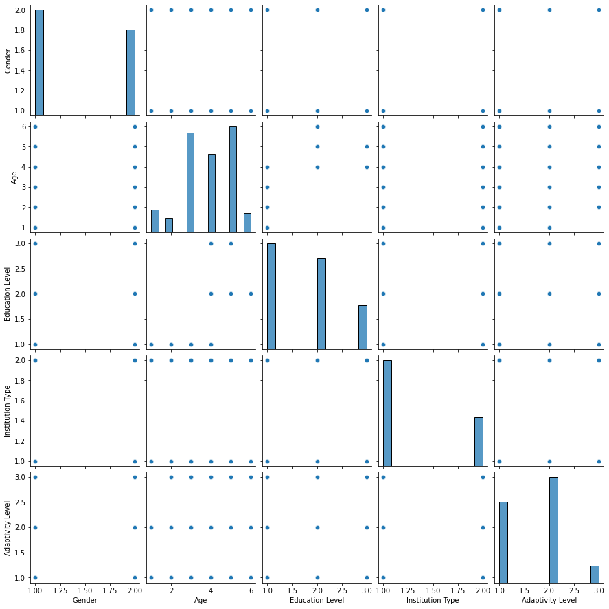

```python
sns.pairplot(adapt_first_part)
plt.show()
```

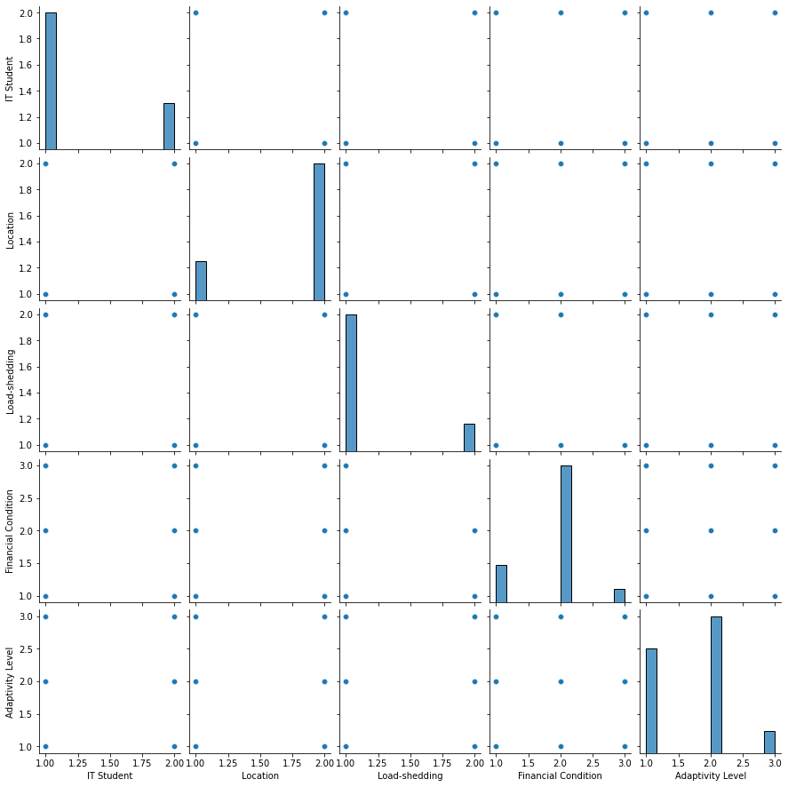

```python
sns.pairplot(adapt_second_part)
plt.show()
```

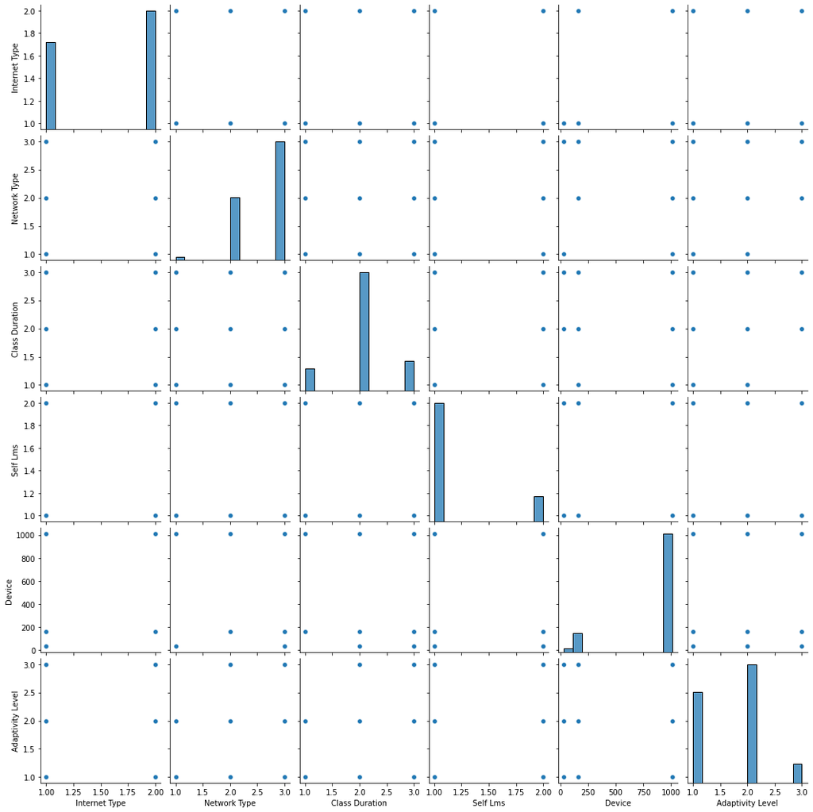

```python
sns.pairplot(adapt_third_part)
plt.show()
```

```python
adapttability_df = pd.read_csv("students_adaptability_level_online_education.csv")
adapttability_df["Adaptivity Level"].replace("Low",  1, inplace = True)
adapttability_df["Adaptivity Level"].replace("Moderate",  2, inplace = True)
adapttability_df["Adaptivity Level"].replace("High",  3, inplace = True)
```